# African Languages: A Statistical Overview

Abdallah Ramadhan

2026-05-03

## 1. Introduction

Africa is the worldâ€™s most linguistically diverse continent, home to an estimated 2,000 languages spanning dozens of distinct language families. This report analyses a dataset of 502 African languages across 51 countries, exploring three core questions:

- Which country in Africa has the largest number of spoken languages?
- Which language family has the highest density of speakers?
- Are there languages that cut across multiple countries?

## 2. Data Preparation

The dataset was loaded from a CSV file containing 796 rows and 4 variables: `language`, `family`, `native_speakers`, and `country`.

### 2.1 Loading the Data

```r
data <- read_csv("../data/africa_languages.csv",
                 locale = locale(encoding = "UTF-8"))
glimpse(data)
```

```
## Rows: 796
## Columns: 4
## $ language        <chr> "Ç‚KxÊ¼aoÇÊ¼ae", "Ç‚KxÊ¼aoÇÊ¼ae", "Abon", "Abron", "Abron", â€¦
## $ family          <chr> "KxÊ¼a", "KxÊ¼a", "Nigerâ€“Congo", "Nigerâ€“Congo", "Nigerâ€“Câ€¦
## $ native_speakers <dbl> 5000, 5000, 800, 1393000, 1393000, 20000, 300000, 2500â€¦
## $ country         <chr> "Namibia", "Botswana", "Cameroon", "Ghana", "Ivory Coaâ€¦
```

### 2.2 Data Quality Issues Identified

Before analysis, the following issues were identified and resolved:

[output not shown]

### 2.3 Cleaning Code

```r
data_clean <- data %>%
  mutate(family = case_when(
    language == "Shabo"                  ~ "Nilo-Saharan",
    language == "Bozo"                   ~ "Niger\u2013Congo",
    language == "Kituba"                 ~ "Kongo-Creole/Pidgin",
    language == "Nubi"                   ~ "Arabic-Creole/Pidgin",
    language == "Krio"                   ~ "English-Creole/Pidgin",
    language == "Pichinglis"             ~ "English-Creole/Pidgin",
    language == "Mauritian Creole"       ~ "French-Creole/Pidgin",
    language == "Seychellois Creole"     ~ "French-Creole/Pidgin",
    language == "Cape Verdean Creole"    ~ "Portuguese-Creole/Pidgin",
    family   == "Afro-Asiatic"           ~ "Afroasiatic",
    TRUE ~ family
  )) %>%
  distinct(language, country, .keep_all = TRUE)
```

### 2.4 Final Dataset Summary

```r
data_clean %>%
  summarise(
    total_rows       = n(),
    unique_languages = n_distinct(language),
    unique_countries = n_distinct(country),
    unique_families  = n_distinct(family)
  )
```

```
## # A tibble: 1 Ã— 4
##   total_rows unique_languages unique_countries unique_families
##        <int>            <int>            <int>           <int>
## 1        760              502               51              15
```

## 3. Exploratory Data Analysis

### 3.1 Distribution of Native Speakers

The `native_speakers` variable is heavily right-skewed, with a median of 150,000 but a mean of nearly 5 million â€” driven by a small number of languages with massive speaker bases like Arabic and Swahili.

```r
summary(data_clean$native_speakers)
```

```
##      Min.   1st Qu.    Median      Mean   3rd Qu.      Max.
##        12     17000    150000   4907792   1300000 150000000
```

A log transformation normalises the distribution and is used throughout this analysis for visualisation and comparison purposes.

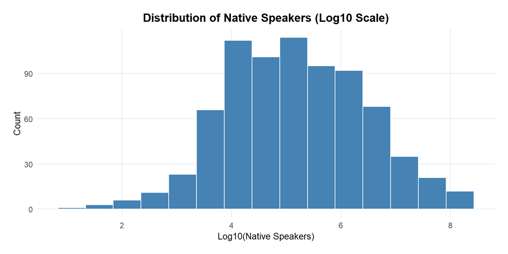

```r
data_clean %>%
  mutate(log_speakers = log10(native_speakers)) %>%
  ggplot(aes(x = log_speakers)) +
  geom_histogram(bins = 15, fill = "steelblue", color = "white") +
  labs(
    title = "Distribution of Native Speakers (Log10 Scale)",
    x     = "Log10(Native Speakers)",
    y     = "Count"
  ) +
  theme_african
```

## 4. Research Findings

### 4.1 Which Country Has the Most Languages?

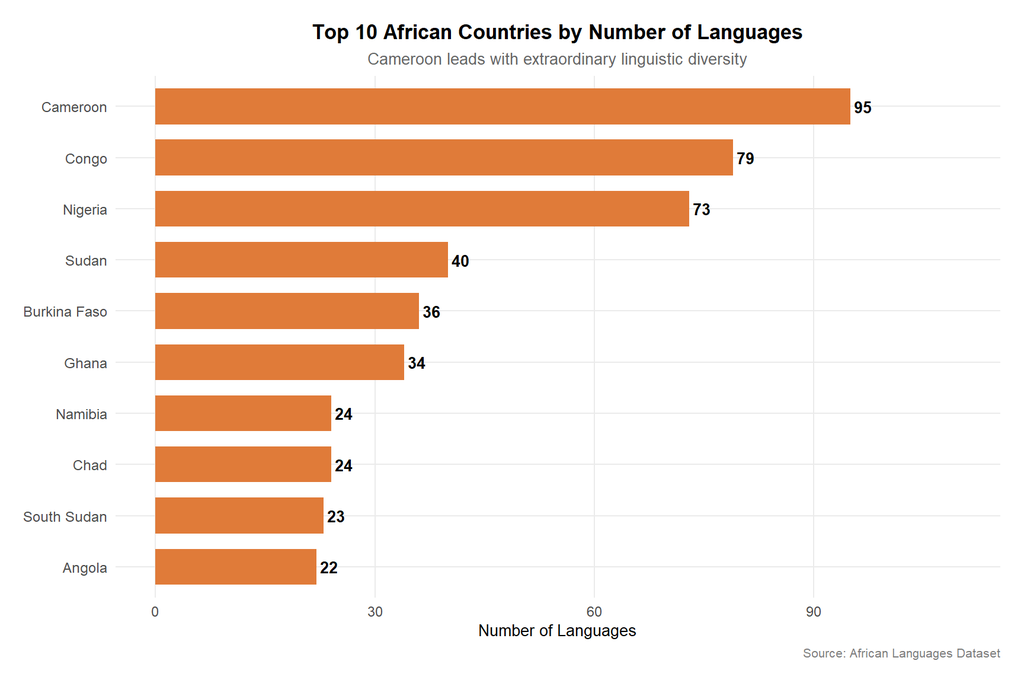

```r
p1 <- data_clean %>%
  group_by(country) %>%
  summarise(num_languages = n_distinct(language)) %>%
  arrange(desc(num_languages)) %>%
  slice_head(n = 10) %>%
  ggplot(aes(x = reorder(country, num_languages), y = num_languages)) +
  geom_col(fill = "#E07B39", width = 0.7) +
  geom_text(aes(label = num_languages),
            hjust = -0.2, size = 3.5, fontface = "bold") +
  coord_flip() +
  scale_y_continuous(limits = c(0, 110)) +
  labs(
    title    = "Top 10 African Countries by Number of Languages",
    subtitle = "Cameroon leads with extraordinary linguistic diversity",
    x        = NULL,
    y        = "Number of Languages",
    caption  = "Source: African Languages Dataset"
  ) +
  theme_african
p1
```

Cameroon leads with **95 languages**, followed by Congo (79) and Nigeria (73). Cameroon’s extraordinary diversity reflects its position at the intersection of West and Central African linguistic zones, earning it the nickname *“Africa in miniature”*. For organisations working in education, health communication or community development, this concentration of diversity means multilingual programming is not optional — it is essential.

### 4.2 Which Language Family Has the Highest Speaker Density?

```r
data_clean %>%
  group_by(family) %>%
  summarise(
    `Number of Languages` = n_distinct(language),
    `Median Speakers`     = scales::comma(median(native_speakers)),
    `Total Speakers`      = scales::comma(sum(native_speakers))
  ) %>%
  arrange(desc(`Number of Languages`)) %>%
  knitr::kable(caption = "Language Family Statistics")
```

Language Family Statistics

| family | Number of Languages | Median Speakers | Total Speakers |
| --- | --- | --- | --- |
| Niger–Congo | 384 | 135,000 | 1,214,230,982 |
| Nilo-Saharan | 71 | 110,000 | 111,091,400 |
| Afroasiatic | 21 | 21,937,940 | 2,267,072,360 |
| Ubangian | 6 | 26,500 | 1,230,000 |
| Indo-European | 4 | 12,100,000 | 101,665,300 |
| Khoe–Kwadi | 4 | 8,000 | 259,500 |
| KxÊ¼a | 4 | 16,500 | 107,500 |
| English-Creole/Pidgin | 2 | 433,000 | 866,000 |
| French-Creole/Pidgin | 2 | 586,500 | 1,173,000 |
| Arabic-Creole/Pidgin | 1 | 50,000 | 100,000 |
| Arabic-based | 1 | 250,000 | 250,000 |
| Austronesian | 1 | 18,000,000 | 18,000,000 |
| Kongo-Creole/Pidgin | 1 | 13,000,000 | 13,000,000 |
| Portuguese-Creole/Pidgin | 1 | 871,000 | 871,000 |
| Tuu | 1 | 2,500 | 5,000 |

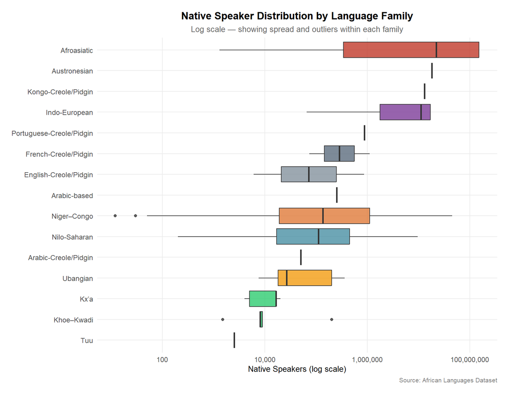

```r
p3 <- data_clean %>%
  ggplot(aes(x = reorder(family, native_speakers, median),
             y = native_speakers,
             fill = family)) +
  geom_boxplot(show.legend = FALSE, alpha = 0.8) +
  scale_y_log10(labels = scales::comma) +
  scale_fill_manual(values = africa_colours) +
  coord_flip() +
  labs(
    title    = "Native Speaker Distribution by Language Family",
    subtitle = "Log scale â€” showing spread and outliers within each family",
    x        = NULL,
    y        = "Native Speakers (log scale)",
    caption  = "Source: African Languages Dataset"
  ) +
  theme_african
p3
```

The answer depends on the metric used. **Afroasiatic** has the highest median speakers per language (~22 million), driven by Arabic. **Niger-Congo** contains the most languages (384) but most are small communities, with a median of only 135,000 speakers â€” revealing a striking paradox between linguistic diversity and speaker density.

### 4.3 Which Languages Span Multiple Countries?

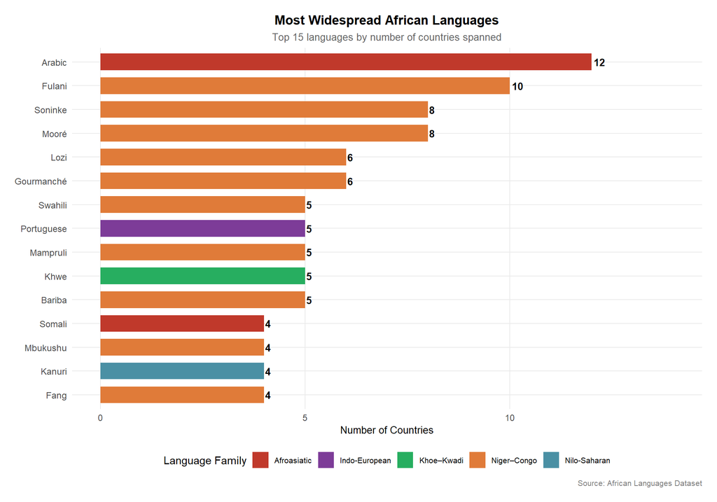

```r
p2 <- data_clean %>%
  group_by(language) %>%
  summarise(
    num_countries = n_distinct(country),
    family        = first(family)
  ) %>%
  filter(num_countries > 1) %>%
  arrange(desc(num_countries)) %>%
  slice_head(n = 15) %>%
  ggplot(aes(x = reorder(language, num_countries),
             y = num_countries,
             fill = family)) +
  geom_col(width = 0.7) +
  geom_text(aes(label = num_countries),
            hjust = -0.2, size = 3.5, fontface = "bold") +
  coord_flip() +
  scale_fill_manual(values = africa_colours) +
  scale_y_continuous(limits = c(0, 14)) +
  labs(
    title    = "Most Widespread African Languages",
    subtitle = "Top 15 languages by number of countries spanned",
    x        = NULL,
    y        = "Number of Countries",
    fill     = "Language Family",
    caption  = "Source: African Languages Dataset"
  ) +
  theme_african +
  theme(legend.position = "bottom",
        legend.text = element_text(size = 8))
p2
```

Of 502 languages, **155 (31%) span more than one country**. Arabic is the most widespread at 12 countries, followed by Fulani at 10. Notably, **347 languages (69%) are endemic to a single country** â€” confined to one national context with no cross-border community to sustain them. These languages are the most vulnerable to extinction through policy neglect and demographic change.

> **For NGO programming:** Endemic languages warrant priority attention in cultural preservation, mother-tongue education, and community documentation initiatives.

## 5. Conclusion

This analysis reveals three defining features of African linguistic diversity:

1. **Concentration of diversity** — Cameroon, Congo and Nigeria together account for a disproportionate share of the continent’s languages. Organisations operating in these countries face the most complex multilingual environments on the continent.
2. **The Niger-Congo paradox** â€” The largest family by language count contains mostly small, localised communities with limited institutional support. Scale of diversity does not translate to security of survival.
3. **Endemic fragility** — 69% of languages are confined to a single country, highlighting the vulnerability of Africa’s linguistic heritage and the urgency of preservation efforts.

### Recommendations for Further Analysis

- Incorporate **language endangerment status** data from UNESCO to identify which endemic languages are most at risk
- Map languages geographically to identify border communities split by colonial boundaries
- Cross-reference with **education policy data** to assess which languages have formal recognition in school systems

### Limitations

- Speaker counts represent a single point in time and may be outdated
- The dataset may not be exhaustive — some estimates put Africa’s languages at over 2,000
- Creole/Pidgin classification required manual research and judgement calls

*Report generated using R 4.6.0 and tidyverse 2.0.0*